# Risk Factor Analysis

## Outcome Variable

**Outcome Variable:** stunted

## Predictor Variables

**Intervention Variable:** nrooms

**Adjustment Set:**

- arm
- sex
- W_mage
- meducyrs
- feducyrs
- hhwealth_quart
- hfoodsec
- W_mhtcm
- W_mwtkg
- W_mbmi
- W_nchldlt5
- W_parity
- impfloor
- impsan
- safeh20
- delta_W_mage
- delta_meducyrs
- delta_feducyrs
- delta_hhwealth_quart
- delta_hfoodsec
- delta_W_mhtcm
- delta_W_mwtkg
- delta_W_mbmi
- delta_W_nchldlt5
- delta_W_parity
- delta_impfloor
- delta_impsan
- delta_safeh20

## Stratifying Variables

The analysis was stratified on these variable(s):

- agecat
- studyid
- country

## Data Summary

| agecat | studyid | country | nrooms | stunted | n_cell | n |
| --- | --- | --- | --- | --- | --- | --- |
| Birth | CMC-V-BCS-2002 | INDIA | 4+ | 0 | 4 | 92 |
| Birth | CMC-V-BCS-2002 | INDIA | 4+ | 1 | 1 | 92 |
| Birth | CMC-V-BCS-2002 | INDIA | 1 | 0 | 32 | 92 |
| Birth | CMC-V-BCS-2002 | INDIA | 1 | 1 | 6 | 92 |
| Birth | CMC-V-BCS-2002 | INDIA | 2 | 0 | 22 | 92 |
| Birth | CMC-V-BCS-2002 | INDIA | 2 | 1 | 7 | 92 |
| Birth | CMC-V-BCS-2002 | INDIA | 3 | 0 | 17 | 92 |
| Birth | CMC-V-BCS-2002 | INDIA | 3 | 1 | 3 | 92 |
| Birth | COHORTS | INDIA | 4+ | 0 | 84 | 4769 |
| Birth | COHORTS | INDIA | 4+ | 1 | 8 | 4769 |
| Birth | COHORTS | INDIA | 1 | 0 | 2705 | 4769 |
| Birth | COHORTS | INDIA | 1 | 1 | 420 | 4769 |
| Birth | COHORTS | INDIA | 2 | 0 | 1263 | 4769 |
| Birth | COHORTS | INDIA | 2 | 1 | 122 | 4769 |
| Birth | COHORTS | INDIA | 3 | 0 | 152 | 4769 |
| Birth | COHORTS | INDIA | 3 | 1 | 15 | 4769 |
| Birth | CONTENT | PERU | 4+ | 0 | 1 | 2 |
| Birth | CONTENT | PERU | 4+ | 1 | 0 | 2 |
| Birth | CONTENT | PERU | 1 | 0 | 0 | 2 |
| Birth | CONTENT | PERU | 1 | 1 | 0 | 2 |
| Birth | CONTENT | PERU | 2 | 0 | 1 | 2 |
| Birth | CONTENT | PERU | 2 | 1 | 0 | 2 |
| Birth | CONTENT | PERU | 3 | 0 | 0 | 2 |
| Birth | CONTENT | PERU | 3 | 1 | 0 | 2 |
| Birth | GMS-Nepal | NEPAL | 4+ | 0 | 276 | 696 |
| Birth | GMS-Nepal | NEPAL | 4+ | 1 | 45 | 696 |
| Birth | GMS-Nepal | NEPAL | 1 | 0 | 42 | 696 |
| Birth | GMS-Nepal | NEPAL | 1 | 1 | 7 | 696 |
| Birth | GMS-Nepal | NEPAL | 2 | 0 | 113 | 696 |
| Birth | GMS-Nepal | NEPAL | 2 | 1 | 32 | 696 |

[output cut: 354 more lines]

The following strata were considered:

- agecat: 24 months, studyid: CMC-V-BCS-2002, country: INDIA
- agecat: 24 months, studyid: COHORTS, country: INDIA
- agecat: 24 months, studyid: CONTENT, country: PERU
- agecat: 24 months, studyid: GMS-Nepal, country: NEPAL
- agecat: 24 months, studyid: IRC, country: INDIA
- agecat: 24 months, studyid: JiVitA-3, country: BANGLADESH
- agecat: 24 months, studyid: JiVitA-4, country: BANGLADESH
- agecat: 24 months, studyid: MAL-ED, country: BANGLADESH
- agecat: 24 months, studyid: MAL-ED, country: BRAZIL
- agecat: 24 months, studyid: MAL-ED, country: INDIA
- agecat: 24 months, studyid: MAL-ED, country: NEPAL
- agecat: 24 months, studyid: MAL-ED, country: PERU
- agecat: 24 months, studyid: MAL-ED, country: SOUTH AFRICA
- agecat: 24 months, studyid: MAL-ED, country: TANZANIA, UNITED REPUBLIC OF
- agecat: 24 months, studyid: NIH-Crypto, country: BANGLADESH
- agecat: 24 months, studyid: PROVIDE, country: BANGLADESH
- agecat: 6 months, studyid: CMC-V-BCS-2002, country: INDIA
- agecat: 6 months, studyid: COHORTS, country: INDIA
- agecat: 6 months, studyid: CONTENT, country: PERU
- agecat: 6 months, studyid: GMS-Nepal, country: NEPAL
- agecat: 6 months, studyid: IRC, country: INDIA
- agecat: 6 months, studyid: JiVitA-3, country: BANGLADESH
- agecat: 6 months, studyid: JiVitA-4, country: BANGLADESH
- agecat: 6 months, studyid: MAL-ED, country: BANGLADESH
- agecat: 6 months, studyid: MAL-ED, country: BRAZIL
- agecat: 6 months, studyid: MAL-ED, country: INDIA
- agecat: 6 months, studyid: MAL-ED, country: NEPAL
- agecat: 6 months, studyid: MAL-ED, country: PERU
- agecat: 6 months, studyid: MAL-ED, country: SOUTH AFRICA
- agecat: 6 months, studyid: MAL-ED, country: TANZANIA, UNITED REPUBLIC OF
- agecat: 6 months, studyid: NIH-Crypto, country: BANGLADESH
- agecat: 6 months, studyid: PROVIDE, country: BANGLADESH
- agecat: Birth, studyid: CMC-V-BCS-2002, country: INDIA
- agecat: Birth, studyid: COHORTS, country: INDIA
- agecat: Birth, studyid: CONTENT, country: PERU
- agecat: Birth, studyid: GMS-Nepal, country: NEPAL
- agecat: Birth, studyid: IRC, country: INDIA
- agecat: Birth, studyid: JiVitA-3, country: BANGLADESH
- agecat: Birth, studyid: JiVitA-4, country: BANGLADESH
- agecat: Birth, studyid: MAL-ED, country: BANGLADESH
- agecat: Birth, studyid: MAL-ED, country: BRAZIL
- agecat: Birth, studyid: MAL-ED, country: INDIA
- agecat: Birth, studyid: MAL-ED, country: NEPAL
- agecat: Birth, studyid: MAL-ED, country: PERU
- agecat: Birth, studyid: MAL-ED, country: SOUTH AFRICA
- agecat: Birth, studyid: MAL-ED, country: TANZANIA, UNITED REPUBLIC OF
- agecat: Birth, studyid: NIH-Crypto, country: BANGLADESH
- agecat: Birth, studyid: PROVIDE, country: BANGLADESH

### Dropped Strata

Some strata were dropped due to rare outcomes:

- agecat: Birth, studyid: CMC-V-BCS-2002, country: INDIA
- agecat: Birth, studyid: CONTENT, country: PERU
- agecat: Birth, studyid: IRC, country: INDIA
- agecat: Birth, studyid: MAL-ED, country: BANGLADESH
- agecat: Birth, studyid: MAL-ED, country: BRAZIL
- agecat: Birth, studyid: MAL-ED, country: INDIA
- agecat: Birth, studyid: MAL-ED, country: NEPAL
- agecat: Birth, studyid: MAL-ED, country: PERU
- agecat: Birth, studyid: MAL-ED, country: SOUTH AFRICA
- agecat: Birth, studyid: MAL-ED, country: TANZANIA, UNITED REPUBLIC OF
- agecat: Birth, studyid: PROVIDE, country: BANGLADESH
- agecat: 6 months, studyid: CMC-V-BCS-2002, country: INDIA
- agecat: 6 months, studyid: CONTENT, country: PERU
- agecat: 6 months, studyid: IRC, country: INDIA
- agecat: 6 months, studyid: MAL-ED, country: BANGLADESH
- agecat: 6 months, studyid: MAL-ED, country: BRAZIL
- agecat: 6 months, studyid: MAL-ED, country: INDIA
- agecat: 6 months, studyid: MAL-ED, country: NEPAL
- agecat: 6 months, studyid: MAL-ED, country: SOUTH AFRICA
- agecat: 6 months, studyid: MAL-ED, country: TANZANIA, UNITED REPUBLIC OF
- agecat: 6 months, studyid: PROVIDE, country: BANGLADESH
- agecat: 24 months, studyid: CONTENT, country: PERU
- agecat: 24 months, studyid: MAL-ED, country: BANGLADESH
- agecat: 24 months, studyid: MAL-ED, country: BRAZIL
- agecat: 24 months, studyid: MAL-ED, country: TANZANIA, UNITED REPUBLIC OF

## Methods Detail

We’re interested in the causal parameters $E[Y_a]$ for all values of $a \in \mathcal{A}$. These parameters represent the mean outcome if, possibly contrary to fact, we intervened to set all units to have $A=a$. Under the randomization and positivity assumptions, these are identified by the statistical parameters $\psi_a=E_W[E_{Y|A,W}(Y|A=a,W)]$. In addition, we’re interested in the mean of $Y$, $E[Y]$ under no intervention (the observed mean). We will estimate these parameters by using SuperLearner to fit the relevant likelihood factors – $E_{Y|A,W}(Y|A=a,W)$ and $p(A=a|W)$, and then updating our likelihood fit using a joint TMLE.

For unadjusted analyses ($W=\{\}$), initial likelihoods were estimated using Lrnr_glm to estimate the simple $E(Y|A)$ and Lrnr_mean to estimate $p(A)$. For adjusted analyses, a small library containing Lrnr_glmnet, Lrnr_xgboost, and Lrnr_mean was used.

Having estimated these parameters, we will then use the delta method to estimate relative risks and attributable risks relative to a prespecified baseline level of $A$.

# Results Detail

## Results Plots

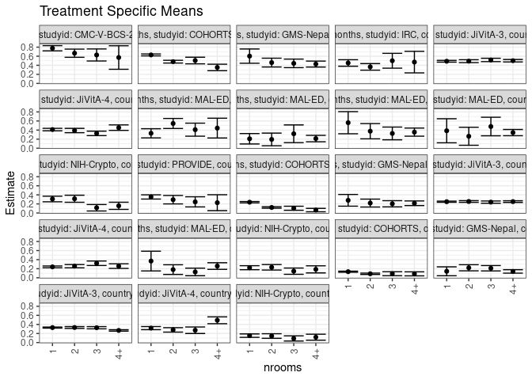

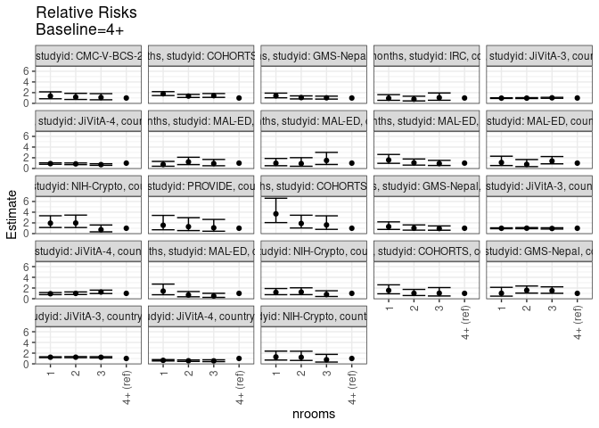

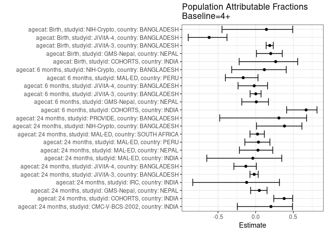

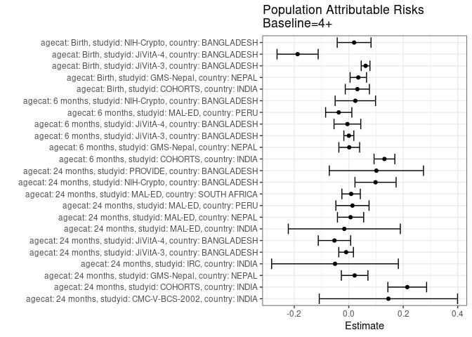

## Results Table

### Parameter: TSM

| agecat | studyid | country | intervention_level | baseline_level | estimate | ci_lower | ci_upper |
| --- | --- | --- | --- | --- | --- | --- | --- |
| Birth | COHORTS | INDIA | 4+ | NA | 0.0869565 | 0.0425224 | 0.1313907 |
| Birth | COHORTS | INDIA | 1 | NA | 0.1344000 | 0.1224401 | 0.1463599 |
| Birth | COHORTS | INDIA | 2 | NA | 0.0880866 | 0.0731587 | 0.1030146 |
| Birth | COHORTS | INDIA | 3 | NA | 0.0898204 | 0.0464507 | 0.1331901 |
| Birth | GMS-Nepal | NEPAL | 4+ | NA | 0.1401869 | 0.1021799 | 0.1781939 |
| Birth | GMS-Nepal | NEPAL | 1 | NA | 0.1428571 | 0.0448089 | 0.2409054 |
| Birth | GMS-Nepal | NEPAL | 2 | NA | 0.2206897 | 0.1531401 | 0.2882392 |
| Birth | GMS-Nepal | NEPAL | 3 | NA | 0.2099448 | 0.1505699 | 0.2693196 |
| Birth | JiVitA-3 | BANGLADESH | 4+ | NA | 0.2673741 | 0.2519630 | 0.2827852 |
| Birth | JiVitA-3 | BANGLADESH | 1 | NA | 0.3302894 | 0.3189823 | 0.3415965 |
| Birth | JiVitA-3 | BANGLADESH | 2 | NA | 0.3319742 | 0.3119366 | 0.3520118 |
| Birth | JiVitA-3 | BANGLADESH | 3 | NA | 0.3271685 | 0.3029404 | 0.3513966 |
| Birth | JiVitA-4 | BANGLADESH | 4+ | NA | 0.4912210 | 0.4155359 | 0.5669060 |
| Birth | JiVitA-4 | BANGLADESH | 1 | NA | 0.3183896 | 0.2841002 | 0.3526790 |
| Birth | JiVitA-4 | BANGLADESH | 2 | NA | 0.2796344 | 0.2307053 | 0.3285634 |
| Birth | JiVitA-4 | BANGLADESH | 3 | NA | 0.2716110 | 0.1997967 | 0.3434253 |
| Birth | NIH-Crypto | BANGLADESH | 4+ | NA | 0.1182796 | 0.0526010 | 0.1839582 |
| Birth | NIH-Crypto | BANGLADESH | 1 | NA | 0.1529745 | 0.1153981 | 0.1905509 |
| Birth | NIH-Crypto | BANGLADESH | 2 | NA | 0.1443850 | 0.0939741 | 0.1947959 |
| Birth | NIH-Crypto | BANGLADESH | 3 | NA | 0.0909091 | 0.0342415 | 0.1475767 |
| 6 months | COHORTS | INDIA | 4+ | NA | 0.0645161 | 0.0270802 | 0.1019521 |
| 6 months | COHORTS | INDIA | 1 | NA | 0.2380952 | 0.2233666 | 0.2528239 |
| 6 months | COHORTS | INDIA | 2 | NA | 0.1221167 | 0.1054000 | 0.1388333 |
| 6 months | COHORTS | INDIA | 3 | NA | 0.1043956 | 0.0599677 | 0.1488235 |
| 6 months | GMS-Nepal | NEPAL | 4+ | NA | 0.2144963 | 0.1635125 | 0.2654801 |
| 6 months | GMS-Nepal | NEPAL | 1 | NA | 0.2795370 | 0.1502129 | 0.4088611 |
| 6 months | GMS-Nepal | NEPAL | 2 | NA | 0.2189984 | 0.1316811 | 0.3063157 |
| 6 months | GMS-Nepal | NEPAL | 3 | NA | 0.2032190 | 0.1347630 | 0.2716749 |
| 6 months | JiVitA-3 | BANGLADESH | 4+ | NA | 0.2510899 | 0.2327434 | 0.2694365 |
| 6 months | JiVitA-3 | BANGLADESH | 1 | NA | 0.2490505 | 0.2367085 | 0.2613926 |

[output cut: 62 more lines]

### Parameter: E(Y)

| agecat | studyid | country | intervention_level | baseline_level | estimate | ci_lower | ci_upper |
| --- | --- | --- | --- | --- | --- | --- | --- |
| Birth | COHORTS | INDIA | NA | NA | 0.1184735 | 0.1093005 | 0.1276464 |
| Birth | GMS-Nepal | NEPAL | NA | NA | 0.1752874 | 0.1470202 | 0.2035545 |
| Birth | JiVitA-3 | BANGLADESH | NA | NA | 0.3291721 | 0.3217884 | 0.3365557 |
| Birth | JiVitA-4 | BANGLADESH | NA | NA | 0.3035461 | 0.2835868 | 0.3235054 |
| Birth | NIH-Crypto | BANGLADESH | NA | NA | 0.1379781 | 0.1129774 | 0.1629789 |
| 6 months | COHORTS | INDIA | NA | NA | 0.1954857 | 0.1844503 | 0.2065211 |
| 6 months | GMS-Nepal | NEPAL | NA | NA | 0.2163121 | 0.1823021 | 0.2503220 |
| 6 months | JiVitA-3 | BANGLADESH | NA | NA | 0.2514286 | 0.2432985 | 0.2595587 |
| 6 months | JiVitA-4 | BANGLADESH | NA | NA | 0.2524352 | 0.2383740 | 0.2664965 |
| 6 months | MAL-ED | PERU | NA | NA | 0.2222222 | 0.1725409 | 0.2719036 |
| 6 months | NIH-Crypto | BANGLADESH | NA | NA | 0.2097902 | 0.1799252 | 0.2396552 |
| 24 months | CMC-V-BCS-2002 | INDIA | NA | NA | 0.7169811 | 0.6710815 | 0.7628807 |
| 24 months | COHORTS | INDIA | NA | NA | 0.5670048 | 0.5511355 | 0.5828741 |
| 24 months | GMS-Nepal | NEPAL | NA | NA | 0.4487705 | 0.4045970 | 0.4929440 |
| 24 months | IRC | INDIA | NA | NA | 0.4201474 | 0.3721360 | 0.4681589 |
| 24 months | JiVitA-3 | BANGLADESH | NA | NA | 0.4911833 | 0.4780660 | 0.5043006 |
| 24 months | JiVitA-4 | BANGLADESH | NA | NA | 0.4008848 | 0.3839144 | 0.4178552 |
| 24 months | MAL-ED | INDIA | NA | NA | 0.4273128 | 0.3628178 | 0.4918077 |
| 24 months | MAL-ED | NEPAL | NA | NA | 0.2192982 | 0.1654718 | 0.2731246 |
| 24 months | MAL-ED | PERU | NA | NA | 0.3681592 | 0.3013164 | 0.4350020 |
| 24 months | MAL-ED | SOUTH AFRICA | NA | NA | 0.3529412 | 0.2921001 | 0.4137823 |
| 24 months | NIH-Crypto | BANGLADESH | NA | NA | 0.2568093 | 0.2190047 | 0.2946140 |
| 24 months | PROVIDE | BANGLADESH | NA | NA | 0.3287197 | 0.2903909 | 0.3670485 |

### Parameter: RR

| agecat | studyid | country | intervention_level | baseline_level | estimate | ci_lower | ci_upper |
| --- | --- | --- | --- | --- | --- | --- | --- |
| Birth | COHORTS | INDIA | 4+ | 4+ | 1.0000000 | 1.0000000 | 1.0000000 |
| Birth | COHORTS | INDIA | 1 | 4+ | 1.5456000 | 0.9201016 | 2.5963213 |
| Birth | COHORTS | INDIA | 2 | 4+ | 1.0129964 | 0.5912897 | 1.7354635 |
| Birth | COHORTS | INDIA | 3 | 4+ | 1.0329341 | 0.5113859 | 2.0863949 |
| Birth | GMS-Nepal | NEPAL | 4+ | 4+ | 1.0000000 | 1.0000000 | 1.0000000 |
| Birth | GMS-Nepal | NEPAL | 1 | 4+ | 1.0190476 | 0.4872017 | 2.1314747 |
| Birth | GMS-Nepal | NEPAL | 2 | 4+ | 1.5742529 | 1.0459129 | 2.3694822 |
| Birth | GMS-Nepal | NEPAL | 3 | 4+ | 1.4976059 | 1.0121675 | 2.2158619 |
| Birth | JiVitA-3 | BANGLADESH | 4+ | 4+ | 1.0000000 | 1.0000000 | 1.0000000 |
| Birth | JiVitA-3 | BANGLADESH | 1 | 4+ | 1.2353081 | 1.1563259 | 1.3196851 |
| Birth | JiVitA-3 | BANGLADESH | 2 | 4+ | 1.2416093 | 1.1437488 | 1.3478429 |
| Birth | JiVitA-3 | BANGLADESH | 3 | 4+ | 1.2236356 | 1.1166141 | 1.3409145 |
| Birth | JiVitA-4 | BANGLADESH | 4+ | 4+ | 1.0000000 | 1.0000000 | 1.0000000 |
| Birth | JiVitA-4 | BANGLADESH | 1 | 4+ | 0.6481596 | 0.5370851 | 0.7822055 |
| Birth | JiVitA-4 | BANGLADESH | 2 | 4+ | 0.5692639 | 0.4523548 | 0.7163876 |
| Birth | JiVitA-4 | BANGLADESH | 3 | 4+ | 0.5529304 | 0.4071059 | 0.7509888 |
| Birth | NIH-Crypto | BANGLADESH | 4+ | 4+ | 1.0000000 | 1.0000000 | 1.0000000 |
| Birth | NIH-Crypto | BANGLADESH | 1 | 4+ | 1.2933299 | 0.7047110 | 2.3736004 |
| Birth | NIH-Crypto | BANGLADESH | 2 | 4+ | 1.2207098 | 0.6335011 | 2.3522175 |
| Birth | NIH-Crypto | BANGLADESH | 3 | 4+ | 0.7685950 | 0.3335395 | 1.7711193 |
| 6 months | COHORTS | INDIA | 4+ | 4+ | 1.0000000 | 1.0000000 | 1.0000000 |
| 6 months | COHORTS | INDIA | 1 | 4+ | 3.6904762 | 2.0589789 | 6.6147422 |
| 6 months | COHORTS | INDIA | 2 | 4+ | 1.8928087 | 1.0427652 | 3.4357925 |
| 6 months | COHORTS | INDIA | 3 | 4+ | 1.6181319 | 0.7879522 | 3.3229819 |
| 6 months | GMS-Nepal | NEPAL | 4+ | 4+ | 1.0000000 | 1.0000000 | 1.0000000 |
| 6 months | GMS-Nepal | NEPAL | 1 | 4+ | 1.3032254 | 0.7748379 | 2.1919376 |
| 6 months | GMS-Nepal | NEPAL | 2 | 4+ | 1.0209893 | 0.6416039 | 1.6247081 |
| 6 months | GMS-Nepal | NEPAL | 3 | 4+ | 0.9474242 | 0.6276238 | 1.4301763 |
| 6 months | JiVitA-3 | BANGLADESH | 4+ | 4+ | 1.0000000 | 1.0000000 | 1.0000000 |
| 6 months | JiVitA-3 | BANGLADESH | 1 | 4+ | 0.9918778 | 0.9119716 | 1.0787852 |

[output cut: 62 more lines]

### Parameter: PAR

| agecat | studyid | country | intervention_level | baseline_level | estimate | ci_lower | ci_upper |
| --- | --- | --- | --- | --- | --- | --- | --- |
| Birth | COHORTS | INDIA | 4+ | NA | 0.0315170 | -0.0127529 | 0.0757868 |
| Birth | GMS-Nepal | NEPAL | 4+ | NA | 0.0351004 | 0.0049159 | 0.0652850 |
| Birth | JiVitA-3 | BANGLADESH | 4+ | NA | 0.0617979 | 0.0457885 | 0.0778074 |
| Birth | JiVitA-4 | BANGLADESH | 4+ | NA | -0.1876749 | -0.2631114 | -0.1122383 |
| Birth | NIH-Crypto | BANGLADESH | 4+ | NA | 0.0196986 | -0.0422903 | 0.0816874 |
| 6 months | COHORTS | INDIA | 4+ | NA | 0.1309696 | 0.0928493 | 0.1690899 |
| 6 months | GMS-Nepal | NEPAL | 4+ | NA | 0.0018158 | -0.0362706 | 0.0399021 |
| 6 months | JiVitA-3 | BANGLADESH | 4+ | NA | 0.0003386 | -0.0179796 | 0.0186568 |
| 6 months | JiVitA-4 | BANGLADESH | 4+ | NA | -0.0049390 | -0.0540023 | 0.0441244 |
| 6 months | MAL-ED | PERU | 4+ | NA | -0.0367706 | -0.0848383 | 0.0112971 |
| 6 months | NIH-Crypto | BANGLADESH | 4+ | NA | 0.0242158 | -0.0499483 | 0.0983799 |
| 24 months | CMC-V-BCS-2002 | INDIA | 4+ | NA | 0.1455526 | -0.1082204 | 0.3993255 |
| 24 months | COHORTS | INDIA | 4+ | NA | 0.2146070 | 0.1435202 | 0.2856938 |
| 24 months | GMS-Nepal | NEPAL | 4+ | NA | 0.0216497 | -0.0271232 | 0.0704227 |
| 24 months | IRC | INDIA | 4+ | NA | -0.0504408 | -0.2828754 | 0.1819938 |
| 24 months | JiVitA-3 | BANGLADESH | 4+ | NA | -0.0096806 | -0.0365336 | 0.0171723 |
| 24 months | JiVitA-4 | BANGLADESH | 4+ | NA | -0.0523616 | -0.1118189 | 0.0070958 |
| 24 months | MAL-ED | INDIA | 4+ | NA | -0.0162419 | -0.2217822 | 0.1892984 |
| 24 months | MAL-ED | NEPAL | 4+ | NA | 0.0066998 | -0.0414388 | 0.0548384 |
| 24 months | MAL-ED | PERU | 4+ | NA | 0.0136137 | -0.0472857 | 0.0745132 |
| 24 months | MAL-ED | SOUTH AFRICA | 4+ | NA | 0.0086789 | -0.0251192 | 0.0424769 |
| 24 months | NIH-Crypto | BANGLADESH | 4+ | NA | 0.0982728 | 0.0228208 | 0.1737247 |
| 24 months | PROVIDE | BANGLADESH | 4+ | NA | 0.1014470 | -0.0713219 | 0.2742159 |

### Parameter: PAF

| agecat | studyid | country | intervention_level | baseline_level | estimate | ci_lower | ci_upper |
| --- | --- | --- | --- | --- | --- | --- | --- |
| Birth | COHORTS | INDIA | 4+ | NA | 0.2660254 | -0.2191932 | 0.5581351 |
| Birth | GMS-Nepal | NEPAL | 4+ | NA | 0.2002451 | 0.0105904 | 0.3535460 |
| Birth | JiVitA-3 | BANGLADESH | 4+ | NA | 0.1877375 | 0.1388226 | 0.2338740 |
| Birth | JiVitA-4 | BANGLADESH | 4+ | NA | -0.6182747 | -0.8963178 | -0.3809990 |
| Birth | NIH-Crypto | BANGLADESH | 4+ | NA | 0.1427659 | -0.4468845 | 0.4921154 |
| 6 months | COHORTS | INDIA | 4+ | NA | 0.6699701 | 0.4116068 | 0.8148861 |
| 6 months | GMS-Nepal | NEPAL | 4+ | NA | 0.0083943 | -0.1842778 | 0.1697202 |
| 6 months | JiVitA-3 | BANGLADESH | 4+ | NA | 0.0013468 | -0.0742228 | 0.0716002 |
| 6 months | JiVitA-4 | BANGLADESH | 4+ | NA | -0.0195652 | -0.2337626 | 0.1574447 |
| 6 months | MAL-ED | PERU | 4+ | NA | -0.1654676 | -0.4018717 | 0.0310705 |
| 6 months | NIH-Crypto | BANGLADESH | 4+ | NA | 0.1154286 | -0.3182806 | 0.4064492 |
| 24 months | CMC-V-BCS-2002 | INDIA | 4+ | NA | 0.2030075 | -0.2437129 | 0.4892736 |
| 24 months | COHORTS | INDIA | 4+ | NA | 0.3784924 | 0.2402270 | 0.4915959 |
| 24 months | GMS-Nepal | NEPAL | 4+ | NA | 0.0482423 | -0.0669701 | 0.1510141 |
| 24 months | IRC | INDIA | 4+ | NA | -0.1200550 | -0.8356451 | 0.3165763 |
| 24 months | JiVitA-3 | BANGLADESH | 4+ | NA | -0.0197088 | -0.0760041 | 0.0336411 |
| 24 months | JiVitA-4 | BANGLADESH | 4+ | NA | -0.1306150 | -0.2897222 | 0.0088639 |
| 24 months | MAL-ED | INDIA | 4+ | NA | -0.0380095 | -0.6494649 | 0.3467799 |
| 24 months | MAL-ED | NEPAL | 4+ | NA | 0.0305512 | -0.2157265 | 0.2269388 |
| 24 months | MAL-ED | PERU | 4+ | NA | 0.0369779 | -0.1435142 | 0.1889812 |
| 24 months | MAL-ED | SOUTH AFRICA | 4+ | NA | 0.0245902 | -0.0760360 | 0.1158062 |
| 24 months | NIH-Crypto | BANGLADESH | 4+ | NA | 0.3826681 | 0.0113978 | 0.6145076 |
| 24 months | PROVIDE | BANGLADESH | 4+ | NA | 0.3086124 | -0.4777979 | 0.6765344 |